# Knowledge Graph-Enhanced Hate Incident Classification

2025-12-17

## The Original Vision

**Initial Research Goal**

This project originally set out to evaluate whether **relational context** improves the classification of hate terminology compared to traditional text-only approaches.

Specifically:

- Use ADL’s **expert-vetted incident database** as high-quality ground truth
- Compare **flat text classification** against a **graph-enhanced semantic model**
- Test whether contextual relationships improve:
  - Classification accuracy
  - Disambiguation of coded or ambiguous terms
  - Interpretability of results

The working hypothesis was that **meaning in hate speech is relational**, not purely lexical — and that models ignoring context would underperform.

## ADL HEAT Map: Real-Time Hate Tracking

**What It Is:** - **H**ate, **E**xtremism, **A**ntisemitism, **T**errorism Map - Interactive tool tracking incidents in real-time across the U.S.

**Data Categories Tracked:** - Antisemitic Incidents (harassment, vandalism, assault) - White Supremacist Propaganda & Events - Extremist Murders & Terrorist Plots

**Current Scale:** 12,476 incidents (2024-2025)

**Our Value Add:** - HEAT shows **WHERE** and **WHEN** - We add **WHAT TYPE** (23 granular categories) - Enables faster triage and targeted response

**Explore:** [adl.org/heat-map](https://www.adl.org/resources/tools-to-track-hate/heat-map)

[figure not shown]

## ADL Glossary of Extremism and Hate

**What It Is:** - Comprehensive database of hate terminology, symbols, and extremist movements - Expert-curated definitions with context, ideology, and severity ratings

**Content Coverage:** - 1,142+ terms across 23 categories - Groups/Movements, Numbers/Symbols, Slogans/Code Words - Conspiracy Theories, Publications, Tactics

**Our Use:** - **Foundation** of the knowledge graph - Each term becomes a node with rich semantic context - Incident descriptions matched against glossary via embeddings - Enables granular classification vs. broad “hate” labels

**Explore:** [adl.org/resources/hate-symbols](https://www.adl.org/resources/hate-symbols/search)

[figure not shown]

## The Pivot: A Critical Realization

As implementation progressed, a more fundamental issue emerged:

**Accuracy was not the bottleneck — scalability and generalization were.**

### The Scale Problem

[output not shown]

## What Actually Changed

The project did **not** abandon machine learning.

Instead, it reframed the problem:

- The goal shifted from **predicting labels** → **projecting expert knowledge**
- From training on past incidents → **generalizing to unseen language**
- From static accuracy → **operational decision support**

The knowledge graph became the mechanism for:

- Encoding ADL’s expert understanding as **semantic structure**
- Allowing new incidents to be interpreted **relative to known concepts**
- Producing classifications *with confidence and traceability*

**The model learned meaning — not just labels**

## The Urgent Need

- Bondi Beach, Australia – Mass Shooting, 10yr old girl and a Holocaust Survivor killed
- Redlands, California – House displaying a Menorah shot 40 times
- Amsterdam, Netherlands – Protestors attack Hanukah celebrations
- Global surge – Incidents up 360% since October 2023

We can’t wait years to manually catalog every new hate term.  
We need to process thousands of incidents NOW.

## The Surge: Why Scale Matters Now

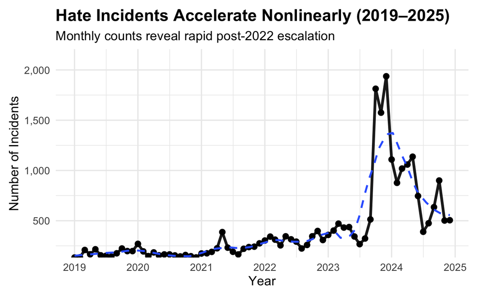

## The Solution: Knowledge Graph Approach

**The Original Plan:** Train a classifier on historical incidents to predict glossary term categories, comparing text-only vs. graph-enhanced accuracy.

**What Actually Happened:** The glossary couldn’t scale fast enough to label the exponential surge in new incidents.

**The Pivot:** Instead of predicting static labels, we:

- Flipped the model: Use the glossary as the **knowledge base**, not the target
- Encode ADL’s expert-curated terminology as **semantic embeddings**
- Build a **knowledge graph** connecting terms, categories, and relationships
- Match **new incidents** to existing expert knowledge via semantic similarity
- Project expert intelligence forward rather than training backward on labels

**Result:** Expert Intelligence × Machine Speed = Scalable Processing

## Dataset Scale & Scope

### Three Core Datasets

**1. Historical Training Data**

- 16,893 incidents (2020-2023)
- Expert-vetted by ADL’s Center on Extremism
- Geographic: All 50 states + D.C.

**2. ADL Hate Terms Glossary**

- 1,142 expert-curated terms
- 23 granular categories
- Rich definitions with context and examples

**3. New Incidents for Testing**

- 9,603 incidents (2024)
- Processed by human AND machine
- Direct comparison dataset

**Human Labels:** Single “Antisemitism” category

- Groups / Movements (Patriot Front, Proud Boys, GDL)
- Numbers / Symbols (14/88, swastika)
- Slogans / Code Words (Holocaust denial phrases)
- Publications (antisemitic literature)
- Conspiracy Theories (QAnon, Great Replacement)
- Key Concepts / Definitions
- Tactics (doxxing, harassment methods)

**Each term includes: definition, variations, related terms, severity, ideology**

## Data Quality & Coverage

**Temporal Coverage**

- 5 years continuous (2020-2024)
- 16,893 training + 9,603 test incidents

**Geographic Coverage**

- All 50 states + Washington D.C.
- 1,000+ cities represented
- Urban and rural incidents

**Data Completeness**

- 100% for core fields (ID, date, description, location)
- Average description length: ~200 words
- All training data verified by ADL experts

**Expert Validation**

- ADL Center on Extremism reviewed all historical incidents
- Glossary curated by hate/extremism researchers
- Human-processed 2024 data for ground truth comparison

## Human vs Machine: The Classification Gap

**Human Expert Classification** - All 9,603 incidents → **1 category: “Antisemitism”** - Broad label, limited operational detail - Cannot distinguish threat types or prioritize response

## Machine Categories: Operational Detail

**Each category enables targeted threat response and resource allocation**

## The Pipeline: 7 Phases

[interactive chart not shown]

**16,893 historical incidents** → **1,142 glossary terms** → **9,603 new incidents classified**

## Phase Details: Data Foundation

**Phase 1: Data Ingestion** (16,893 historical incidents + 1,142 glossary terms)

- Loads 4 years of ADL incident data and hate terms glossary
- Cleans and standardizes formats (text cleaning, date parsing, location normalization)
- Validates data quality and completeness
- Extracts explicit term mentions from incident descriptions

**Phase 2: Glossary Processing** (Term relationships + taxonomy)

- Analyzes term structure and extracts relationships (synonyms, variations, categories)
- Builds term network graph connecting related concepts
- Enriches terms with incident frequency and contextual examples
- Creates rich embedding text combining definitions, categories, and examples

**Phase 3: Embedding Generation** (SentenceTransformer: all-MiniLM-L6-v2)

- Generates 384-dimensional semantic embeddings for all incidents and terms
- Uses normalized embeddings for consistent similarity scoring
- Computes cosine similarity between incidents and glossary (top-5 matches)
- Outputs similarity scores with confidence metrics

## Phase Details: Graph & Classification

**Phase 4: Knowledge Graph Construction** (21,594 nodes, 28,394 relationships)

- Creates Neo4j nodes: Incidents, Terms, Categories, Locations, Groups
- Establishes relationships: USES_TERM, SIMILAR_TO, BELONGS_TO, OCCURRED_IN
- Links co-occurring terms and related concepts
- Trains graph with historical patterns for contextual classification

**Phase 5: Incident Processing** (9,603 new incidents classified)

- Loads raw unprocessed incidents from past year
- Generates embeddings and matches to glossary terms
- Queries knowledge graph for co-occurrence patterns and frequency
- Adjusts confidence based on training data (frequency boost + category agreement)

**Phase 6: Evaluation** (Statistical validation + performance metrics)

- Compares machine vs. human classifications on same incidents
- Calculates accuracy, precision, recall, F1-scores (macro & weighted)
- Performs statistical tests: McNemar’s, chi-square, paired t-test
- Analyzes accuracy by confidence level (high/medium/low thresholds)

**Phase 7: Export for Analysis** (R-ready formats)

- Exports structured datasets, embeddings, confusion matrices
- Prepares temporal, geographic, and network visualizations
- Creates metadata file linking all outputs

## Key Innovation: Semantic Matching

**Traditional**

```
IF incident.text CONTAINS "swastika"
THEN category = "Numbers / Symbols"
```

**Knowledge Graph**

```
embedding_similarity(incident, glossary_terms)
→ top_match: "swastika" (0.87)
→ category: "Numbers / Symbols"
→ context + related concepts
```

**Captures meaning, not just keywords**

## The Results: Machine vs Human

### Category Granularity

[output not shown]

## What That Granularity Means

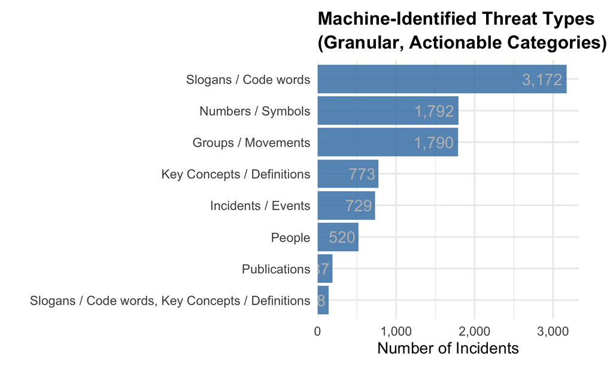

## Confidence Scoring

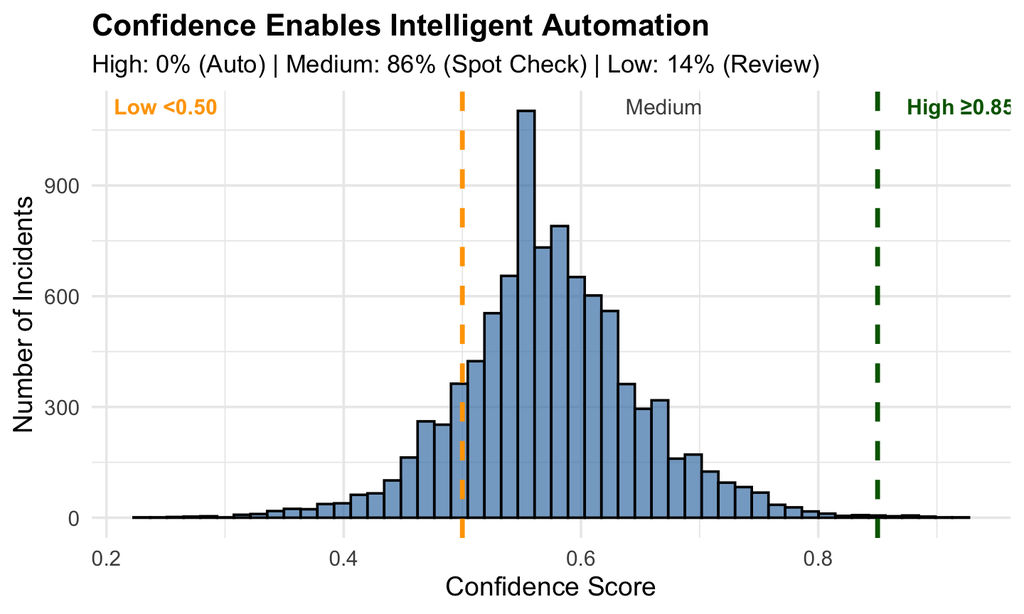

What This Shows: Distribution of machine confidence across 9,603 incidents

## The Bottom Line

In a world where hate incidents are surging…  
Manual processing cannot scale  
Expert Intelligence × Machine Speed = Scalable Action

## Questions?

Project Repository:  
https://github.com/Vaene/CUNY607Final  
https://rpubs.com/randyhowk/1382159